# final_project

## Class Project: Global Fishing Patterns

Roan Hollander

## Introduction: Fishing on a Global Scale

I am looking at fishing patterns worldwide and addressing questions such as: How has the type of fishing gear used changed over time? How has global fishing effort changed from 1950-2017 and how has this been specific to each region? What are the patterns across the three main fishing sectors: Unpowered Artisinal, Powered Artisinal, and Industrial? All of these changes impact what the fishing effort has been across ecological functional groups, as each gear is used to target a different type of catch, and each catch varies regionally.

This is an important analysis because the state of today's global fisheries is increasingly under scrutiny. The timeline of this dataset is important, because after the second World War, technological advances made it possible for fishing fleets to stay at sea for much longer periods of time and catch more fish much more efficiently. This expanded fishing capacity greatly and made fisheries a more valuable economic commodity. Overfishing is depleting fish stocks everywhere, but it has different regional effects and causes and is caused by different gears. How do we analyze fisheries data to gain insights about where efforts to address overfishing and protect artisanal fisheries can be focused? Though my project cannot answer these questions fully, there are important dates and definitions to keep in mind when looking at temporal trends, which I elaborate upon later.

I got my data from The Institute of Marine and Antarctic Studies through Nature magazine. https://metadata.imas.utas.edu.au/geonetwork/srv/eng/catalog.search#/metadata/1241a51d-c8c2-4432-aa68-3d2bae142794

I have only found one paper in which this data was used: https://gmd.copernicus.org/articles/17/1/2024/. This article is looking at simulations of climate scenarios based on agricultural/fishery solutions and uses this data to project future fishing patterns.

## Data Wrangling

For my analyses, I created several DataFrames that are groupings and subsections of the larger frames found in the data. This helped me look at Sector, Gear Type, and Region – my main categorical variables of interest for analyzing trends – more clearly and notice patterns. I joined a DataFrame with regional labels of all of the countries onto the main data set that I was using so I could analyze by that variable.

The relevant quantitative variables analyzed were vessel tonnage, vessel engine power, the effective fishing effort (kW of engine multiplied by days at sea).

```python
#load in the programs

import pandas as pd
import numpy as np
import matplotlib.pyplot as plt
%matplotlib inline
import plotly.express as px
import geopandas as gpd
import seaborn as sns
```

```python
#import the data

fishing_EEZ = pd.read_csv("TotalEffortby_FGroup_EEZ_Sector (1).csv")
fishing_boat = pd.read_csv("TotalEffortby_FGroup_FishingCountry_LengthBoat_Sector.csv")
fishing_totals = pd.read_csv("TotalEffortby_FishingCountry_LengthBoat_Gear_Sector.csv")
country_capacities = pd.read_csv("CapacityCountryLevel_Detailed (1).csv")
region_codes = pd.read_csv("SAUPtoCountry.csv")
```

```python
#merging data frames for analyses, ensuring that countries are matched to their respective region

regions_matched = fishing_totals.merge(region_codes, how = 'right', left_on = 'Country', right_on = 'Country')
regions_matched.head()
```

|  | Unnamed: 0_x | SAUP_x | NomActive | EffActive | Length_Category | Gear | NV | P | GT | Year | Sector | NomActiveHours | EffActiveHours | Country | Unnamed: 0_y | SAUP_y | Region |
| --- | --- | --- | --- | --- | --- | --- | --- | --- | --- | --- | --- | --- | --- | --- | --- | --- | --- |
| 0 | 932.0 | 36.0 | 330373.254161 | 332645.598411 | 12-24m | Gillnets | 114.234 | 1638.312936 | 3145.137756 | 1950.0 | UP | 2.851157e+06 | 2.870768e+06 | AUS | 1 | 36 | AustraliaNZ |
| 1 | 970.0 | 36.0 | 61010.258172 | 62774.087843 | 12-24m | Lines_Handlines_and_poles | 20.967 | 300.703007 | 461.465393 | 1950.0 | UP | 5.265252e+05 | 5.417472e+05 | AUS | 1 | 36 | AustraliaNZ |
| 2 | 984.0 | 36.0 | 14600.732063 | 15022.844757 | 12-24m | Lines_Longlines | 5.061 | 72.583485 | 150.562706 | 1950.0 | UP | 1.260059e+05 | 1.296488e+05 | AUS | 1 | 36 | AustraliaNZ |
| 3 | 1013.0 | 36.0 | 12325.272814 | 12410.047421 | 12-24m | Others_Others | 4.338 | 62.214415 | 188.069890 | 1950.0 | UP | 1.063684e+05 | 1.071001e+05 | AUS | 1 | 36 | AustraliaNZ |
| 4 | 1047.0 | 36.0 | 12657.143484 | 12715.366344 | 12-24m | Pots_and_Traps | 4.338 | 62.214415 | 84.791642 | 1950.0 | UP | 1.092325e+05 | 1.097350e+05 | AUS | 1 | 36 | AustraliaNZ |

```python
fishing_EEZ.head()
```

|  | Unnamed: 0 | EEZ | FGroup | NomActive | EffActive | NV | P | GT | Year | Sector | NomActiveHours | EffActiveHours |
| --- | --- | --- | --- | --- | --- | --- | --- | --- | --- | --- | --- | --- |
| 0 | 1 | NaN | NaN | NaN | NaN | NaN | NaN | NaN | NaN | NaN | NaN | NaN |
| 1 | 2 | Chile | bathydemersal30-90cm | 1.300933e+06 | 1.313937e+06 | 160.205546 | 6491.625170 | 1629.427041 | 1950.0 | APW | 1.140562e+07 | 1.151962e+07 |
| 2 | 3 | Mozambique | bathydemersal30-90cm | 7.429446e+01 | 7.936155e+01 | 0.007649 | 0.363452 | 0.057718 | 1950.0 | APW | 6.260806e+02 | 6.687827e+02 |
| 3 | 4 | Namibia | bathydemersal30-90cm | 6.440214e+01 | 6.879454e+01 | 0.006631 | 0.315058 | 0.050032 | 1950.0 | APW | 8.245915e+02 | 8.808247e+02 |
| 4 | 5 | Peru | bathydemersal30-90cm | 2.779968e+03 | 2.807756e+03 | 0.342344 | 13.871978 | 3.481929 | 1950.0 | APW | 2.386388e+04 | 2.410242e+04 |

## Visualizing the Data

I conducted the visualization process in four steps to answer my research questions.

### 1) Visualizing Regional Vessel Power and Tonnage Trends

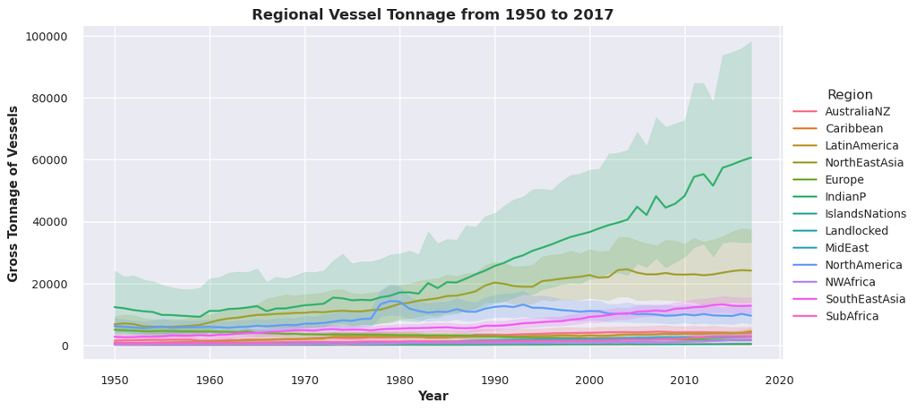

```python
regions_matched = regions_matched[regions_matched.Region != 'Unknown']
g = sns.relplot(data = regions_matched,
            x = 'Year',
            y = 'GT',
            hue = 'Region',
            kind = 'line',
           height = 5,
           aspect = 2);
sns.set_theme("notebook")
plt.style.use("seaborn-v0_8-notebook")
plt.xlabel("Year", fontweight = 'bold');
plt.ylabel("Gross Tonnage of Vessels", fontweight = 'bold');
plt.title("Regional Vessel Tonnage from 1950 to 2017", fontweight = 'bold', fontsize = 13);
```

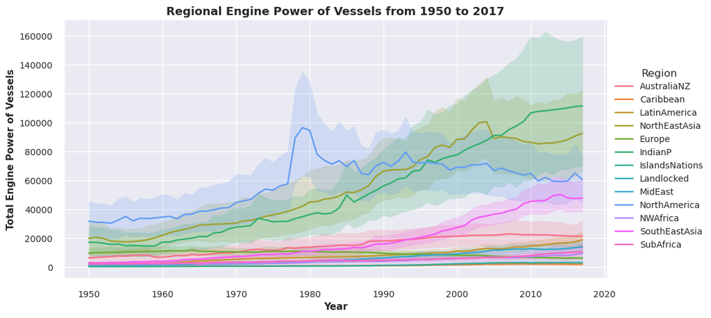

```python
regions_matched = regions_matched[regions_matched.Region != 'Unknown']
sns.relplot(data = regions_matched,
            x = 'Year',
            y = 'P',
            hue = 'Region',
            kind = 'line',
           height = 5,
           aspect = 2);

sns.set_theme("notebook")
plt.style.use("seaborn-v0_8-notebook")
plt.ylabel("Total Engine Power of Vessels", fontweight = 'bold');
plt.xlabel("Year", fontweight = 'bold');
plt.title("Regional Engine Power of Vessels from 1950 to 2017", fontweight = 'bold', fontsize = 13);
```

I used a heatmap to show the changes in the vessel tonnage for each type of gear used. I also grouped some of the confusing gear names so they are aggregate and easier to understand and dropped names that were 'other' as they were not informative for the analyses here. Each gear type has a different ecological impact - the definitions below were taken from NOAA and the UN's FAO. They demonstrate the capacity of each gear type to gather a large quantity of fish and describe where the gear might be used, thus where the ecological impact is felt.

**Bottom Trawling** is a form of indusrial fishing that involves dragging huge nets across the seafloor, catching crabs and fish that live on the seafloor.  
**Dredges** are another method that scrapes the seafloor and targets a variety of shellfish.  
**Falling Gear** includes types of nets and baskets that are dropped atop of target species to capture them.  
**Gillnets** are essentially a wall of net that is dragged through the water column, catching everything found.  
**Lift Nets** are horizontal nets placed in the water column, then raised to catch fish above.  
**Lines** are what we usually think of as fishing, casting a rod of some sort with a hook and bait at the end of it.  
**Midwater Trawling** drags a huge net through the water column to catch the target species.  
**Pots and Traps** are trap cages on the seafloor that are used to catch crustraceans.  
**Seine (Purse, Danish)** fishing encircles a school of fish with a large net, catching them all in a cup-like shape that is pulled to the surface.

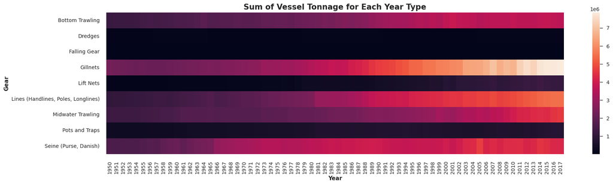

```python
pivot_table2 = gear_copy.pivot_table(index = "Gear", columns = "Year", values = 'GT', aggfunc = 'sum')
fig, ax = plt.subplots(figsize = (20, 5))
g = sns.heatmap(pivot_table2);
g.set_xlabel("Year", fontweight = 'bold');
g.set_ylabel("Gear", fontweight = 'bold');
g.set_title("Sum of Vessel Tonnage for Each Year Type", fontweight = 'bold', fontsize = 15);
```

### 3) Changes Across Fishing Sectors

I used a line graph to analyze how the tonnage of vessels associated with each fishing sector has changed from 1950 to 2017. There are important definitions of what each kind of fishing is to keep in mind in order to understand how these changes have an ecological impact.

**Industrial fishing** is defined as fishing that uses a high level of technology and large boats to catch massive amounts of fish for commercial sale, and is usually run by large corporations. These factors make industrial fishing very high impact. **Artisinal Unpowered fishing** is a low-technology and small scale type of fishing that doesn't use motorized boats and is done more for daily needs than the commercial market that industrial fishing caters to. **Artisinal Powered fishing** is still smaller-scale fishing but uses powered vessels for a higher yield than artisinal unpowered fishing.

Given these definitions, changes in vessel tonnage per sector would have regional variations and high ecological consequences. The rise in industrial fishing has places lots of pressure on pelagic fish populations that are found on the High Seas and may drive artisinal unpowered fishers to use powered equipment or seek other professions if overfishing is too great.

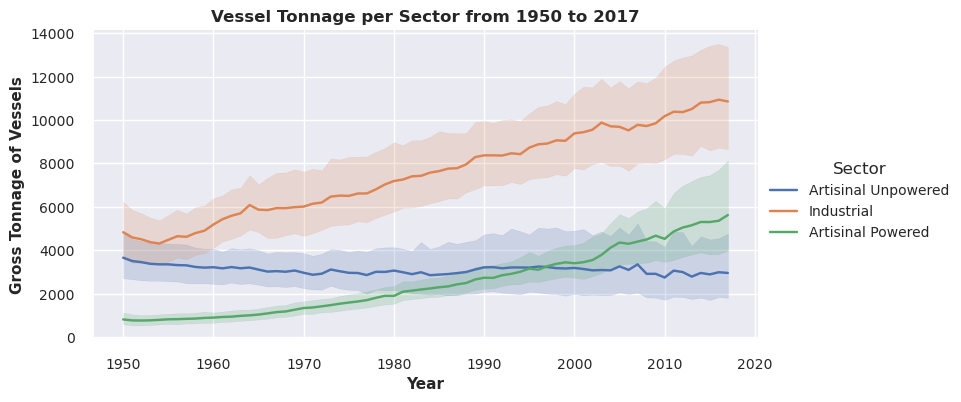

```python
sns.relplot(data = my_copy,
            x = 'Year',
            y = 'GT',
            hue = 'Sector',
            kind = 'line',
           height = 4,
           aspect = 2,
           legend = True);
sns.set_theme("notebook")
plt.style.use("seaborn-v0_8-notebook")
plt.ylabel("Gross Tonnage of Vessels", fontweight = 'bold');
plt.xlabel("Year", fontweight = 'bold');
plt.title("Vessel Tonnage per Sector from 1950 to 2017", fontweight = 'bold', fontsize = 12);
```